# Mortes por COVID-19

Adaptado de Mine Çetinkaya-Rundel

2021-01-17

## Introdução

Países em todo o mundo estão respondendo a um surto de doença respiratória causada por um novo coronavírus, o COVID-19. O surto começou em Wuhan, China, mas foram identificados casos em um número crescente de outros locais internacionalmente, incluindo os Estados Unidos. Neste relatório, exploramos como a trajetória das mortes cumulativas em vários países.

Os dados vêm do pacote `coronavírus`, que coleta dados do repositório de Coronavírus do Centro de Ciência e Engenharia de Sistemas da Universidade Johns Hopkins. O pacote coronavírus fornece um conjunto de dados, em formato organizado, da epidemia de Coronavírus COVID-19 (2019-nCoV) de 2019. O pacote está disponível no GitHub [aqui](https://github.com/RamiKrispin/coronavirus) e é atualizado diariamente.

Para nossa análise, além do pacote de `coronavírus`, utilizaremos os seguintes pacotes para a discussão e visualização de dados.

- `tidyverse` para a discussão e visualização de dados
- `lubridate` pacote para manuseio de datas
- `glue` pacote para a construção de cadeias de texto
- `scales` pacote para formatação de eixos dos gráficos
- `ggrepel` pacote para rótulo dos países nos gráficos

Faremos uso do pacote `DT` para a exibição interativa da saída tabular no Anexo.

```r
library(coronavirus) # devtools::install_github("RamiKrispin/coronavirus")
library(tidyverse)
library(lubridate)
library(glue)
library(scales)
library(ggrepel)
library(DT)
```

## Preparação de dados

A tabela de dados chamado `coronavirus` no pacote coronavirus fornece um resumo diário dos casos de Coronavirus (COVID-19) por país. Cada linha no quadro de dados representa um país (ou, quando relevante, um estado/província). Uma lista completa dos países no quadro de dados é fornecida no Apêndice. Observe que os dados fornecidos neste pacote fornecem o número diário de mortes, casos confirmados e casos recuperados. Para este relatório, vamos nos concentrar nas mortes.

Começaremos por fazer nossa seleção para os países que queremos explorar.

```r
countries <- c(
  "China",
  "France",
  "US",
  "Brazil",
  "Italy"
)
```

No seguinte trecho de código filtramos o quadro de dados para mortes nos países que especificamos acima e calculamos o número cumulativo de mortes. Somente visualizaremos os dados desde a 10ª morte confirmada.

```r
country_data <- coronavirus %>%
  # filter for deaths in countries of interest
  filter(
    type == "death",
    country %in% countries
  ) %>%
  # fix county labels for pretty plotting
  mutate(
    country = case_when(
      country == "United Kingdom" ~ "UK",
      TRUE ~ country
    )
  ) %>%
  # calculate number of total cases for each country and date
  group_by(country, date) %>%
  summarise(tot_cases = sum(cases)) %>%
  # arrange by date in ascending order
  arrange(date) %>%
  # record daily cumulative cases as cumulative_cases
  mutate(cumulative_cases = cumsum(tot_cases)) %>%
  # only use days since the 10th confirmed death
  filter(cumulative_cases > 9) %>%
  # record days elapsed, end date, and end label
  mutate(
    days_elapsed = as.numeric(date - min(date)),
    end_date     = if_else(date == max(date), TRUE, FALSE),
    end_label    = if_else(end_date, country, NULL)
  ) %>%
  # ungroup
  ungroup()
```

Também precisamos tomar nota da “data” dos dados para que possamos rotular adequadamente nossa visualização.

```r
as_of_date <- country_data %>%
  summarise(max(date)) %>%
  pull()

as_of_date_formatted <- glue("{wday(as_of_date, label = TRUE)}, {month(as_of_date, label = TRUE)} {day(as_of_date)}, {year(as_of_date)}")
```

Estes dados são formatados conforme sáb, jan 9, 2021.

## Visualização

A visualização a seguir mostra o número de casos acumulados versus dias decorridos desde a 10ª morte confirmada em cada país. O período de tempo previsto para cada país varia desde que alguns países começaram a ver (e relatar) mortes da COVID-19 muito mais tarde que outros.

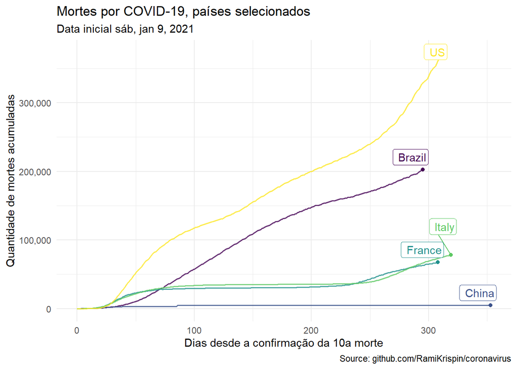

```r
ggplot(data = country_data,
       mapping = aes(x = days_elapsed,
                     y = cumulative_cases,
                     color = country,
                     label = end_label)) +
  # represent cumulative cases with lines
  geom_line(size = 0.7, alpha = 0.8) +
  # add points to line endings
  geom_point(data = country_data %>% filter(end_date)) +
  # add country labels, nudged above the lines
  geom_label_repel(nudge_y = 1, direction = "y", hjust = 1) +
  # turn off legend
  guides(color = FALSE) +
  # use pretty colors
  scale_color_viridis_d() +
  # better formatting for y-axis
  scale_y_continuous(labels = label_comma()) +
  # use minimal theme
  theme_minimal() +
  # customize labels
  labs(
    x = "Dias desde a confirmação da 10a morte",
    y = "Quantidade de mortes acumuladas",
    title = "Mortes por COVID-19, países selecionados",
    subtitle = glue("Data inicial", as_of_date_formatted, .sep = " "),
    caption = "Source: github.com/RamiKrispin/coronavirus"
  )
```

## Apêndice

Uma lista de países no quadro de dados do `coronavírus` é fornecida abaixo.

|  | country |
| --- | --- |
| 1 | Afghanistan |
| 2 | Albania |
| 3 | Algeria |
| 4 | Andorra |
| 5 | Angola |
| 6 | Antigua and Barbuda |
| 7 | Argentina |
| 8 | Armenia |
| 9 | Australia |
| 10 | Austria |

[output cut: 181 more lines]

*Créditos*

Este tutorial é parte do maravilhoso trabalho de Mine Çetinkaya-Rundel: [Data Science Box](https://datasciencebox.org/)